# Data Exploration Project

Yurino Ohmiya, Anna Tran, Aimee Komatsu, An Le

2024-05-22

## Introduction

```r
# see the dataset
str(data)
```

```
## 'data.frame':    4600 obs. of  18 variables:
##  $ date         : chr  "2014-05-02 00:00:00" "2014-05-02 00:00:00" "2014-05-02 00:00:00" "2014-05-02 00:00:00" ...
##  $ price        : num  313000 2384000 342000 420000 550000 ...
##  $ bedrooms     : num  3 5 3 3 4 2 2 4 3 4 ...
##  $ bathrooms    : num  1.5 2.5 2 2.25 2.5 1 2 2.5 2.5 2 ...
##  $ sqft_living  : int  1340 3650 1930 2000 1940 880 1350 2710 2430 1520 ...
##  $ sqft_lot     : int  7912 9050 11947 8030 10500 6380 2560 35868 88426 6200 ...
##  $ floors       : num  1.5 2 1 1 1 1 1 2 1 1.5 ...
##  $ waterfront   : int  0 0 0 0 0 0 0 0 0 0 ...
##  $ view         : int  0 4 0 0 0 0 0 0 0 0 ...
##  $ condition    : int  3 5 4 4 4 3 3 3 4 3 ...
##  $ sqft_above   : int  1340 3370 1930 1000 1140 880 1350 2710 1570 1520 ...
##  $ sqft_basement: int  0 280 0 1000 800 0 0 0 860 0 ...
##  $ yr_built     : int  1955 1921 1966 1963 1976 1938 1976 1989 1985 1945 ...
##  $ yr_renovated : int  2005 0 0 0 1992 1994 0 0 0 2010 ...
##  $ street       : chr  "18810 Densmore Ave N" "709 W Blaine St" "26206-26214 143rd Ave SE" "857 170th Pl NE" ...
##  $ city         : chr  "Shoreline" "Seattle" "Kent" "Bellevue" ...
##  $ statezip     : chr  "WA 98133" "WA 98119" "WA 98042" "WA 98008" ...
##  $ country      : chr  "USA" "USA" "USA" "USA" ...
```

```r
summary(data)
```

```
##      date               price             bedrooms       bathrooms
##  Length:4600        Min.   :       0   Min.   :0.000   Min.   :0.000
##  Class :character   1st Qu.:  322875   1st Qu.:3.000   1st Qu.:1.750
##  Mode  :character   Median :  460943   Median :3.000   Median :2.250
##                     Mean   :  551963   Mean   :3.401   Mean   :2.161
##                     3rd Qu.:  654962   3rd Qu.:4.000   3rd Qu.:2.500
##                     Max.   :26590000   Max.   :9.000   Max.   :8.000
##   sqft_living       sqft_lot           floors        waterfront
##  Min.   :  370   Min.   :    638   Min.   :1.000   Min.   :0.000000
##  1st Qu.: 1460   1st Qu.:   5001   1st Qu.:1.000   1st Qu.:0.000000
##  Median : 1980   Median :   7683   Median :1.500   Median :0.000000
##  Mean   : 2139   Mean   :  14852   Mean   :1.512   Mean   :0.007174
##  3rd Qu.: 2620   3rd Qu.:  11001   3rd Qu.:2.000   3rd Qu.:0.000000
##  Max.   :13540   Max.   :1074218   Max.   :3.500   Max.   :1.000000
##       view          condition       sqft_above   sqft_basement
##  Min.   :0.0000   Min.   :1.000   Min.   : 370   Min.   :   0.0
##  1st Qu.:0.0000   1st Qu.:3.000   1st Qu.:1190   1st Qu.:   0.0
##  Median :0.0000   Median :3.000   Median :1590   Median :   0.0
##  Mean   :0.2407   Mean   :3.452   Mean   :1827   Mean   : 312.1
##  3rd Qu.:0.0000   3rd Qu.:4.000   3rd Qu.:2300   3rd Qu.: 610.0
##  Max.   :4.0000   Max.   :5.000   Max.   :9410   Max.   :4820.0
##     yr_built     yr_renovated       street              city
##  Min.   :1900   Min.   :   0.0   Length:4600        Length:4600
##  1st Qu.:1951   1st Qu.:   0.0   Class :character   Class :character
##  Median :1976   Median :   0.0   Mode  :character   Mode  :character
##  Mean   :1971   Mean   : 808.6
##  3rd Qu.:1997   3rd Qu.:1999.0
##  Max.   :2014   Max.   :2014.0
##    statezip           country
##  Length:4600        Length:4600
##  Class :character   Class :character
##  Mode  :character   Mode  :character
##
##
##
```

```r
# What city names from the city column
unique_cities <- unique(data$city)

# Print the unique city names
print(unique_cities)
```

```
##  [1] "Shoreline"           "Seattle"             "Kent"
##  [4] "Bellevue"            "Redmond"             "Maple Valley"
##  [7] "North Bend"          "Lake Forest Park"    "Sammamish"
## [10] "Auburn"              "Des Moines"          "Bothell"
## [13] "Federal Way"         "Kirkland"            "Issaquah"
## [16] "Woodinville"         "Normandy Park"       "Fall City"
## [19] "Renton"              "Carnation"           "Snoqualmie"
## [22] "Duvall"              "Burien"              "Covington"
## [25] "Inglewood-Finn Hill" "Kenmore"             "Newcastle"
## [28] "Mercer Island"       "Black Diamond"       "Ravensdale"
## [31] "Clyde Hill"          "Algona"              "Skykomish"
## [34] "Tukwila"             "Vashon"              "Yarrow Point"
## [37] "SeaTac"              "Medina"              "Enumclaw"
## [40] "Snoqualmie Pass"     "Pacific"             "Beaux Arts Village"
## [43] "Preston"             "Milton"
```

## Average House Prices by City with Top 10 Highlighted

```r
library(dplyr)
library(ggplot2)
library(scales)

# Summarize average price by city
average_price_by_city <- data %>%
  group_by(city) %>%
  summarise(AveragePrice = mean(price, na.rm = TRUE))

# Summarize average price by ZIP code
average_price_by_zip <- data %>%
  group_by(statezip) %>%
  summarise(AveragePrice = mean(price, na.rm = TRUE))

# View the results
print(average_price_by_city)
```

```
## # A tibble: 44 × 2
##    city               AveragePrice
##    <chr>                     <dbl>
##  1 Algona                  207288
##  2 Auburn                  299340.
##  3 Beaux Arts Village      745000
##  4 Bellevue                847181.
##  5 Black Diamond           339606.
##  6 Bothell                 481442.
##  7 Burien                  348947.
##  8 Carnation               508752.
##  9 Clyde Hill             1321945.
## 10 Covington               296230.
## # ℹ 34 more rows
```

```r
print(average_price_by_zip)
```

```
## # A tibble: 77 × 2
##    statezip AveragePrice
##    <chr>           <dbl>
##  1 WA 98001      257735.
##  2 WA 98002      223547.
##  3 WA 98003      299426.
##  4 WA 98004     1317106.
##  5 WA 98005      778779.
##  6 WA 98006      793053.
##  7 WA 98007      639103.
##  8 WA 98008      602963.
##  9 WA 98010      339606.
## 10 WA 98011      483518.
## # ℹ 67 more rows
```

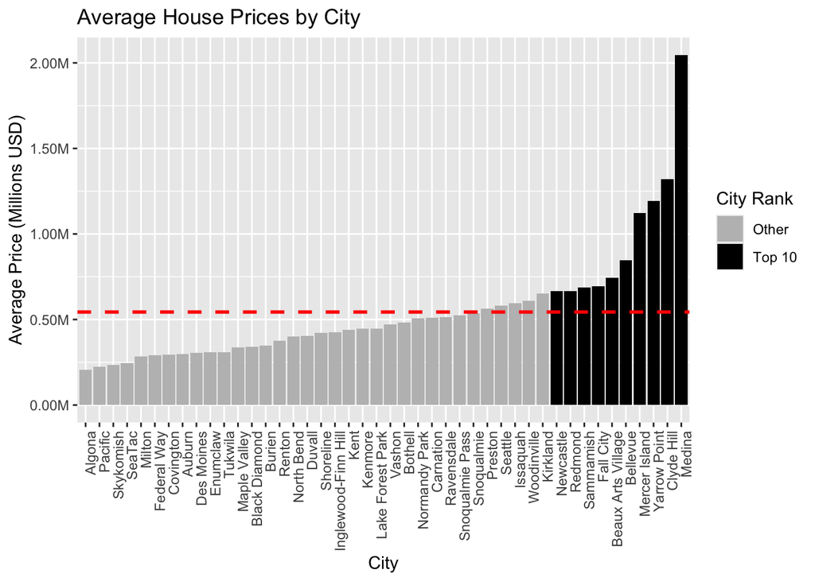

```r
# Plot average price by city
library(dplyr)
library(ggplot2)

# Rank cities by average price
average_price_by_city <- average_price_by_city %>%
  arrange(desc(AveragePrice)) %>%
  mutate(Top10 = ifelse(row_number() <= 10, "Top 10", "Other"))

# Plot average price by city with top 10 cities colored
library(dplyr)
library(ggplot2)

# Convert average price to millions for plotting
average_price_by_city$AveragePrice <- average_price_by_city$AveragePrice / 1e6
overall_avg_price <- mean(average_price_by_city$AveragePrice)

# Plot average price by city with top 10 cities colored, and price in millions
ggplot(average_price_by_city, aes(x = reorder(city, AveragePrice), y = AveragePrice, fill = Top10)) +
  geom_bar(stat = "identity") +
  geom_hline(yintercept = overall_avg_price, linetype = "dashed", color = "red", size = 1.0,
             show.legend = TRUE, aes(label = "Overall Average")) +
  scale_y_continuous(labels = scales::dollar_format(suffix = "M", prefix = "", scale = 1)) +
  scale_fill_manual(values = c("Top 10" = "black", "Other" = "grey")) +
  theme(axis.text.x = element_text(angle = 90, hjust = 1)) +
  labs(x = "City", y = "Average Price (Millions USD)", title = "Average House Prices by City") +
  guides(fill = guide_legend(title = "City Rank"))
```

# Note 1

Black Bars represent the cities that are among the top 10 in terms of average house price. These cities have the highest average prices in the data set. Gray bars: These represent all other cities in the data set that are not in the top 10 for average house prices. Red dashed line: This represents the average price of the overall housing.

From this graph, we can see that many cities have average house prices below the overall average, while only a few selected cities are substatially above this average. Cities significantly above the line, like Medina, Yarrow Point, and MErcert Island, are likely ot have unique attributes that drive higher prices, such as luxury amenities, waterfront access or the larger living spaces.

We can check what variables are most likely to affect the housing price so that we can give insights to prospective buyers.

## Impact of Home Features on Price with Linear Regression

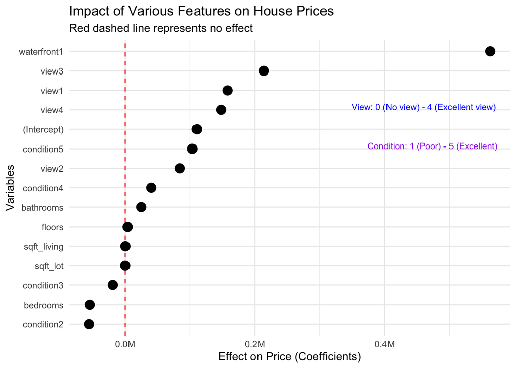

```r
library(ggplot2)
library(broom)
library(caret)
library(scales)

data <- data %>%
  mutate(bathrooms = as.numeric(bathrooms),
         bedrooms = as.numeric(bedrooms),
         sqft_living = as.numeric(sqft_living),
         sqft_lot = as.numeric(sqft_lot),
         floors = as.numeric(floors),
         waterfront = as.factor(waterfront),
         view = as.factor(view),
         condition = as.factor(condition))

# Splitting the dataset into training and testing sets
set.seed(123)  # for reproducibility
indexes <- createDataPartition(data$price, p=0.8, list=FALSE)
train <- data[indexes,]
test <- data[-indexes,]


# Fit the model
model <- lm(price ~ bedrooms + bathrooms + sqft_living + sqft_lot + floors + waterfront + view + condition, data=train)

# Get tidy summary of the model
tidy_model <- tidy(model)

format_millions_one_decimal <- function(x) {
  paste0(format(round(x / 1e6, 1), nsmall = 1), "M")
}

# Create a coefficient plot with 'M' formatted x-axis, one decimal place
plot <- ggplot(tidy_model, aes(x=estimate, y=reorder(term, estimate))) +
  geom_vline(xintercept = 0, linetype="dashed", color = "red") +
  geom_point(size = 4) +
  scale_x_continuous(labels = format_millions_one_decimal) +  # This formats the x-axis labels to millions with 'M'
  labs(y = "Variables", x = "Effect on Price (Coefficients)",
       title = "Impact of Various Features on House Prices",
       subtitle = "Red dashed line represents no effect") +
  theme_minimal()

# Add annotations for 'view' and 'condition' descriptions
plot <- plot +
  annotate("text", x = Inf, y = "view4", label = "View: 0 (No view) - 4 (Excellent view)", hjust = 1.1, vjust = 0, color = "blue", size = 3) +
  annotate("text", x = Inf, y = "condition5", label = "Condition: 1 (Poor) - 5 (Excellent)", hjust = 1.1, vjust = 0, color = "purple", size = 3)

# Print the plot
print(plot)
```

```r
# Predictions and result dataframe
predictions <- predict(model, newdata=test)
result <- data.frame(Actual = test$price, Predicted = predictions)

# Output the first few rows of the result to see prediction performance
head(result)
```

```
##    Actual Predicted
## 1  313000  312762.6
## 4  420000  560920.7
## 7  335000  385634.4
## 8  482000  615680.5
## 19 257950  326905.9
## 22 435000  330995.3
```

```r
# Load the necessary library
library(dplyr)

# Example of fitting a multiple regression model
model <- lm(price ~ waterfront + view + condition + bathrooms + floors + sqft_living + sqft_lot + bedrooms, data = data)
```

## Mapping the Top Cities with High Housing Prices

```r
#install.packages("ggplot2")
#install.packages("sf")
#install.packages("ggmap")

library(leaflet)
library(sf)
# Define data for the cities
top_cities <- data.frame(
  city = c("Newcastle", "Redmond", "Sammamish", "Fall City", "Beaux Arts Village",
           "Bellevue", "Mercer Island", "Yarrow Point", "Clyde Hill", "Medina"),
  latitude = c(47.5301, 47.6740, 47.6163, 47.5676, 47.5913,
               47.6101, 47.5707, 47.6209, 47.6309, 47.6205),
  longitude = c(-122.1635, -122.1215, -122.0338, -121.8887, -122.2009,
                -122.2015, -122.2338, -122.2330, -122.2196, -122.2364)
)

# Create the map
map <- leaflet(top_cities) %>%
  addTiles() %>%
  addMarkers(~longitude, ~latitude, popup = ~city)

# Print the map
map
```

[interactive chart not shown]

## Note 3

This map clearly illustrates that the top 10 cities with the highest housing prices are located along the waterfront or near a lake. This suggests that homes in these areas likely have better views, contributing to their higher prices. Also, it’s clear that the areas with high housing prices are not scattered but are clustered together. This is important information for those looking to find the most affordable housing options. We can also see how other variables might affect the housing price.

## Price Trends of High-Condition Houses Over the Years

```r
# Filter data for houses with the highest condition rating
high_cond_houses <- data[data$condition == 5,]

# Summarize the data to see average, median, range etc., of prices, sizes, etc.
summary(high_cond_houses)
```

```
##      date               price            bedrooms       bathrooms
##  Length:435         Min.   :      0   Min.   :1.000   Min.   :0.750
##  Class :character   1st Qu.: 377475   1st Qu.:3.000   1st Qu.:1.750
##  Mode  :character   Median : 550000   Median :3.000   Median :2.000
##                     Mean   : 637041   Mean   :3.478   Mean   :2.107
##                     3rd Qu.: 744975   3rd Qu.:4.000   3rd Qu.:2.500
##                     Max.   :3200000   Max.   :8.000   Max.   :5.250
##   sqft_living      sqft_lot           floors      waterfront view    condition
##  Min.   : 370   Min.   :   1664   Min.   :1.000   0:432      0:370   1:  0
##  1st Qu.:1540   1st Qu.:   5000   1st Qu.:1.000   1:  3      1:  8   2:  0
##  Median :1980   Median :   7315   Median :1.000              2: 30   3:  0
##  Mean   :2109   Mean   :  14294   Mean   :1.301              3: 13   4:  0
##  3rd Qu.:2550   3rd Qu.:  10012   3rd Qu.:1.500              4: 14   5:435
##  Max.   :6210   Max.   :1074218   Max.   :3.000
##    sqft_above   sqft_basement     yr_built     yr_renovated     street
##  Min.   : 370   Min.   :   0   Min.   :1900   Min.   :   0   Length:435
##  1st Qu.:1090   1st Qu.:   0   1st Qu.:1924   1st Qu.:   0   Class :character
##  Median :1420   Median : 600   Median :1947   Median :   0   Mode  :character
##  Mean   :1567   Mean   : 542   Mean   :1945   Mean   : 295
##  3rd Qu.:1820   3rd Qu.: 900   3rd Qu.:1964   3rd Qu.:   0
##  Max.   :4760   Max.   :2150   Max.   :2003   Max.   :2002
##      city             statezip           country
##  Length:435         Length:435         Length:435
##  Class :character   Class :character   Class :character
##  Mode  :character   Mode  :character   Mode  :character
##
##
##
```

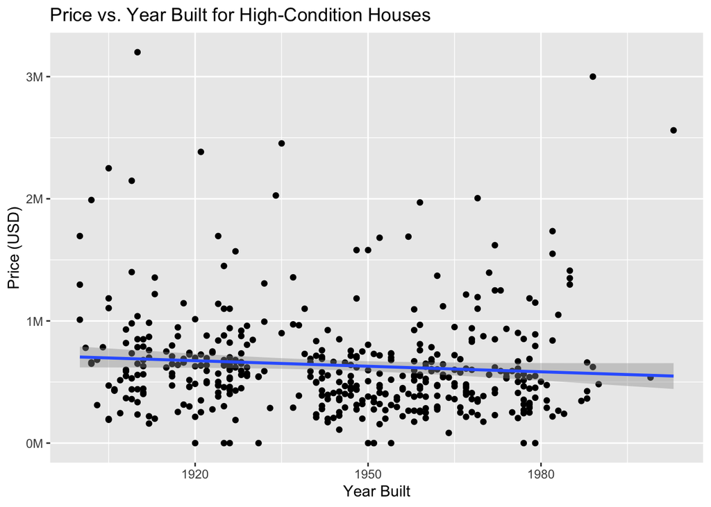

```r
# Plot with y-axis as integer for Price vs. Year Built
library(ggplot2)

# Plot with y-axis as price in millions for Price vs. Year Built
ggplot(high_cond_houses, aes(x = yr_built, y = price / 1e6)) +  # Convert price to millions
  geom_point() +
  geom_smooth(method = "lm") +
  scale_y_continuous(labels = scales::dollar_format(suffix = "M", prefix = "")) +
  ggtitle("Price vs. Year Built for High-Condition Houses") +
  ylab("Price (USD)") +
  xlab("Year Built")
```

## Note 4

From this observation, houses are spread across different years, with no particular concentration in any specific decade. Also, most high-condition houses are priced below $1 million, with a few outliers above $2 million and one above $3 million.

# The relationship between the living area square footage and the price of high-condition houses.

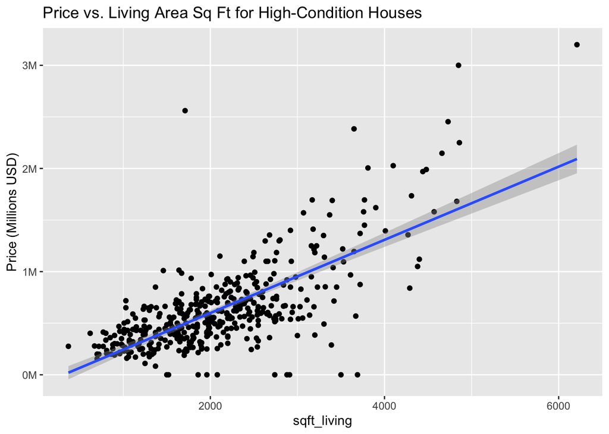

```r
# Square footage and condition
library(ggplot2)

# Adjusting the plot to show price in millions
ggplot(high_cond_houses, aes(x = sqft_living, y = price / 1e6)) +  # Dividing price by 1 million
  geom_point() +  # Adds scatter plot points
  geom_smooth(method = "lm") +  # Adds a linear model line
  scale_y_continuous(labels = scales::dollar_format(suffix = "M", prefix = "")) +  # Formats y-axis labels in millions
  ggtitle("Price vs. Living Area Sq Ft for High-Condition Houses") +  # Adds a title
  ylab("Price (Millions USD)")
```

## Note 5

This graph shows a positive correlation between the square footage of the living area and the price of high-conditioned houses. As the living area increases, the price of the houses also tends to increase, indicated by the upward slope of the blue line. This suggests that larger homes in good condition command higher prices. The shaded area around the line represents the confidence interval, showing the uncertainty or variability in the predictions. The data points are relatively well-clustered around the trend line, especially in the lower square footage range, indicating a consistent relationship across the dataset.

## The relationship betwen square footage and price by renovation status (renovated vs. unrenovated)

```r
data <- data %>%
  mutate(renovation_status = ifelse(yr_renovated == 0, "Unrenovated", "Renovated"))

# Summary statistics of price based on renovation status
price_comparison <- data %>%
  group_by(renovation_status) %>%
  summarise(
    Average_Price = mean(price, na.rm = TRUE),
    Median_Price = median(price, na.rm = TRUE),
    Count = n()
  )

# Output the results
print(price_comparison)
```

```
## # A tibble: 2 × 4
##   renovation_status Average_Price Median_Price Count
##   <chr>                     <dbl>        <dbl> <int>
## 1 Renovated               532441.       445000  1865
## 2 Unrenovated             565275.       480000  2735
```

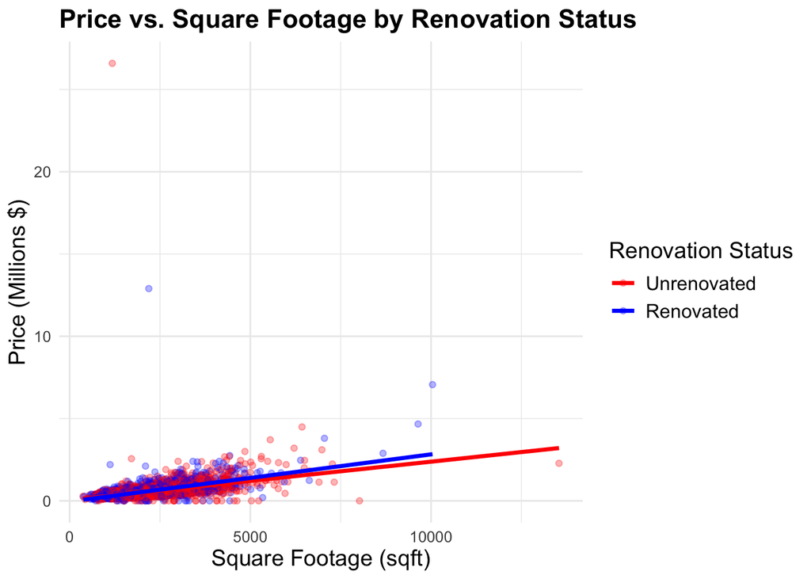

```r
library(dplyr)

# Adding a binary variable for renovation status
data <- data %>%
  mutate(is_renovated = ifelse(yr_renovated > 0, 1, 0))
lm_renovated <- lm(price ~ sqft_living, data = data, subset = is_renovated == 1)
lm_unrenovated <- lm(price ~ sqft_living, data = data, subset = is_renovated == 0)
library(ggplot2)

library(ggplot2)

# Plotting with enhanced visuals
library(ggplot2)

# Plotting with price in millions
ggplot(data, aes(x = sqft_living, y = price / 1e6, color = factor(is_renovated))) +
  geom_point(alpha = 0.3, size = 1.5) +
  geom_smooth(method = "lm", formula = y ~ x, se = FALSE, size = 1.2) +
  scale_color_manual(values = c("red", "blue"),
                     labels = c("Unrenovated", "Renovated"),
                     name = "Renovation Status") +
  labs(
    title = "Price vs. Square Footage by Renovation Status",
    x = "Square Footage (sqft)",
    y = "Price (Millions $)",
    color = "Renovation Status"
  ) +
  theme_minimal() +
  theme(
    text = element_text(size = 12),
    legend.title = element_text(size = 14),
    legend.text = element_text(size = 12),
    plot.title = element_text(size = 16, face = "bold"),
    axis.title = element_text(size = 14)
  )
```

## Note 6

The red dots represent unrenovated houses, and the blue dots represent renovated houses. There is overlap in price cross many square footage ranges, telling that renovation status alone does not significanly affect to the price. Also, in both categories, there is an uupward trend, mening that if the square footage incereases, the prices also increase.

## Comparing Actual and Prediced House Prices

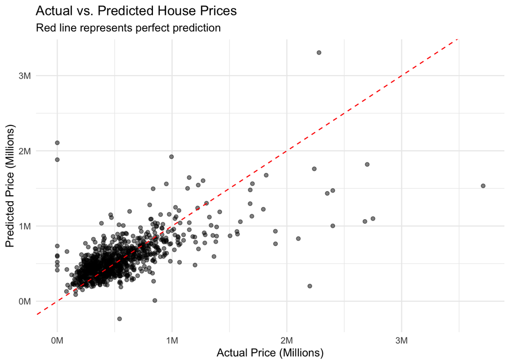

```r
# Plot Actual vs. Predicted Prices
format_millions <- function(x) {
  paste0(round(x / 1e6, 1), "M")  # Round to one decimal place and append 'M'
}

# Plot Actual vs. Predicted Prices with 'M' formatted labels
ggplot(result, aes(x=Actual, y=Predicted)) +
  geom_point(alpha=0.5) +
  geom_abline(slope=1, intercept=0, color="red", linetype="dashed") +
  scale_x_continuous(labels = format_millions) +  # Apply custom formatting to x-axis
  scale_y_continuous(labels = format_millions) +  # Apply custom formatting to y-axis
  labs(x = "Actual Price (Millions)", y = "Predicted Price (Millions)",
       title = "Actual vs. Predicted House Prices",
       subtitle = "Red line represents perfect prediction") +
  theme_minimal()
```

## Note 7

The graph shows how well a model can guess house prices. It does a great job predicting the prices of cheaper houses, up to about $1 million, because most of the dots are close to the line that shows perfect guesses. But for more expensive houses, above $1 million, the predictions aren’t as close. They start to spread out more and have bigger mistakes. This means the model might need some tweaks to better understand what makes those pricey houses special, or to fix any problems in the data it uses to make sure it’s more accurate for high-end homes.